# R Notebook for panic script

This version is for the final check before submitting to Journal lancet psychiatry

```r
library('lmtest');
library(astsa)
library(forecast)
library(dplyr)
library(zoo)
library(TSstudio)
```

In the below, DTPANIC is the master data sheet, from which all variables are derived. OCD and PTSD are same. Please see denominator is the monthly number of total population.

```r
require(readxl)
setwd("~/Dropbox/gitLab/studyDepressionBigData")
DTPANIC<- read_xlsx("PanicWholePopu.xlsx",sheet = "PANIC")
mTotPopulation=DTPANIC$totN1;
nPrevPANIC4=DTPANIC$prevN4/mTotPopulation*100;
nNPrevPANIC4=DTPANIC$inciN4/mTotPopulation*100;
nPrevPANIC3=DTPANIC$prevN3/mTotPopulation*100;
nNPrevPANIC3=DTPANIC$inciN3/mTotPopulation*100;
nPrevPANIC2=DTPANIC$prevN2/mTotPopulation*100;
nNPrevPANIC2=DTPANIC$inciN2/mTotPopulation*100;
nPrevPANIC1=DTPANIC$prevN1/mTotPopulation*100;
nNPrevPANIC1=DTPANIC$inciN1/mTotPopulation*100;
DTOCD<- read_xlsx("PanicWholePopu.xlsx",sheet = "OCD")
nPrevOCD4=DTOCD$prevN4/mTotPopulation*100;
nNPrevOCD4=DTOCD$inciN4/mTotPopulation*100;
nPrevOCD3=DTOCD$prevN3/mTotPopulation*100;
nNPrevOCD3=DTOCD$inciN3/mTotPopulation*100;
nPrevOCD2=DTOCD$prevN2/mTotPopulation*100;
nNPrevOCD2=DTOCD$inciN2/mTotPopulation*100;
nPrevOCD1=DTOCD$prevN1/mTotPopulation*100;
nNPrevOCD1=DTOCD$inciN1/mTotPopulation*100;
DTPTSD<- read_xlsx("PanicWholePopu.xlsx",sheet = "PTSD")
nPrevPTSD4=DTPTSD$prevN4/mTotPopulation*100;
nNPrevPTSD4=DTPTSD$inciN4/mTotPopulation*100;
nPrevPTSD3=DTPTSD$prevN3/mTotPopulation*100;
nNPrevPTSD3=DTPTSD$inciN3/mTotPopulation*100;
nPrevPTSD2=DTPTSD$prevN2/mTotPopulation*100;
nNPrevPTSD2=DTPTSD$inciN2/mTotPopulation*100;
nPrevPTSD1=DTPTSD$prevN1/mTotPopulation*100;
nNPrevPTSD1=DTPTSD$inciN1/mTotPopulation*100;
```

From the file name of the raw data, except search for diagnosis names, celebrities names seemed to be searched, combined with the names of diagnosis.

# READ GOOGLE TREND and CELEB DISCLOSURE

```r
sPanicDis=read.csv(file="~/Dropbox/gitLab/studyDepressionBigData/panicDisorder20142021.csv", header=FALSE);
sOCDDis=read.csv(file="~/Dropbox/gitLab/studyDepressionBigData/OCDDisorder20142029.csv", header=FALSE);
sPanicOCDDis=read.csv(file="~/Dropbox/gitLab/studyDepressionBigData/PanicOCDDisorder20142029.csv", header=FALSE);
sChaPanicDis=read.csv(file="~/Dropbox/gitLab/studyDepressionBigData/googChaPanicDis.csv", header=FALSE);
sLeePanicDis=read.csv(file="~/Dropbox/gitLab/studyDepressionBigData/googLeePanicDis.csv", header=FALSE);
sKimPanicDis=read.csv(file="~/Dropbox/gitLab/studyDepressionBigData/googKimPanicDis.csv", header=FALSE);
```

The number at the end of the file name represents the degree of inclusion criteria. The number four corresponds to the most inclusive criteria. .ts represents the date is converted to time series.

# MAKE DATAFRAME FOR ALL GATHERED INFORMATION

```r
data <- data.frame(
month = as.ts(sPanicDis$V1, format="%Y-%m"),
prevPANIC4 = nPrevPANIC4,
prevPTSD4 = nPrevPTSD4,
prevOCD4 = nPrevOCD4,
prevPANIC3 = nPrevPANIC3,
prevPTSD3 = nPrevPTSD3,
prevOCD3 = nPrevOCD3,
prevPANIC2 = nPrevPANIC2,
prevPTSD2 = nPrevPTSD2,
prevOCD2 = nPrevOCD2,
prevPANIC1 = nPrevPANIC1,
prevPTSD1 = nPrevPTSD1,
prevOCD1 = nPrevOCD1,

inciPANIC4 = nNPrevPANIC4,
inciPTSD4 = nNPrevPTSD4,
inciOCD4 = nNPrevOCD4,
inciPANIC3 = nNPrevPANIC3,
inciPTSD3 = nNPrevPTSD3,
inciOCD3 = nNPrevOCD3,
inciPANIC2 = nNPrevPANIC2,
inciPTSD2 = nNPrevPTSD2,
inciOCD2 = nNPrevOCD2,
inciPANIC1 = nNPrevPANIC1,
inciPTSD1 = nNPrevPTSD1,
inciOCD1 = nNPrevOCD1,

google = sPanicDis$V2,
googleOCD = sOCDDis$V2,
googleOCDrelative = sPanicOCDDis$V3,
googCha = c(sChaPanicDis$V2,rep(0,96)),
googLee = c(sLeePanicDis$V2,rep(0,96)),
googKim = c(sKimPanicDis$V2,rep(0,96))
)

google.ts=ts(data$google,frequency=12, start=c(2004,1))
googleOCD.ts=ts(data$googleOCD,frequency=12, start=c(2004,1))
googleOCDrelative.ts=ts(data$googleOCDrelative,frequency=12, start=c(2004,1))
prevPANIC4.ts=ts(data$prevPANIC4,frequency=12, start=c(2004,1))
prevPTSD4.ts=ts(data$prevPTSD4, frequency = 12, start = c(2004,1))
prevOCD4.ts=ts(data$prevOCD4, frequency = 12, start = c(2004,1))
prevPANIC3.ts=ts(data$prevPANIC3,frequency=12, start=c(2004,1))
prevPTSD3.ts=ts(data$prevPTSD3, frequency = 12, start = c(2004,1))
prevOCD3.ts=ts(data$prevOCD3, frequency = 12, start = c(2004,1))
prevPANIC2.ts=ts(data$prevPANIC2,frequency=12, start=c(2004,1))
prevPTSD2.ts=ts(data$prevPTSD2, frequency = 12, start = c(2004,1))
prevOCD2.ts=ts(data$prevOCD2, frequency = 12, start = c(2004,1))
prevPANIC1.ts=ts(data$prevPANIC1,frequency=12, start=c(2004,1))
prevPTSD1.ts=ts(data$prevPTSD1, frequency = 12, start = c(2004,1))
prevOCD1.ts=ts(data$prevOCD1, frequency = 12, start = c(2004,1))

inciPANIC4.ts=ts(data$inciPANIC4,frequency=12, start=c(2004,1) )
inciPTSD4.ts=ts(data$inciPTSD4,frequency=12, start=c(2004,1) )
inciOCD4.ts=ts(data$inciOCD4,frequency=12, start=c(2004,1) )
inciPANIC3.ts=ts(data$inciPANIC3,frequency=12, start=c(2004,1) )
inciPTSD3.ts=ts(data$inciPTSD3,frequency=12, start=c(2004,1) )
inciOCD3.ts=ts(data$inciOCD3,frequency=12, start=c(2004,1) )
inciPANIC2.ts=ts(data$inciPANIC2,frequency=12, start=c(2004,1) )
inciPTSD2.ts=ts(data$inciPTSD2,frequency=12, start=c(2004,1) )
inciOCD2.ts=ts(data$inciOCD2,frequency=12, start=c(2004,1) )
inciPANIC1.ts=ts(data$inciPANIC1,frequency=12, start=c(2004,1) )
inciPTSD1.ts=ts(data$inciPTSD1,frequency=12, start=c(2004,1) )
inciOCD1.ts=ts(data$inciOCD1,frequency=12, start=c(2004,1) )
```

Below is the just the visualization of the data.

# Draw graph of prevalence

```r
prevNEURO4_3.ts=ts.union(prevPANIC4.ts, prevPTSD4.ts, prevOCD4.ts);
inciNEURO4_3.ts=ts.union(inciPANIC4.ts, inciPTSD4.ts, inciOCD4.ts);
#jpeg(file="~/Dropbox/gitLab/studyDepressionBigData/prevNEURO4_3.jpeg")
plot(prevNEURO4_3.ts, type="l", plot.type="s", col=c("blue","magenta","cyan"), xlab="Month", ylab="Pat. N", linetype=c("solid","dashed"), ylim=c(0,max(prevNEURO4_3.ts[,1])))
legend("topleft", inset = 0.02, legend=c("PANIC","OCD", "PTSD"),
       col=c("blue", "cyan","magenta"), lty=1, cex=0.8)
```

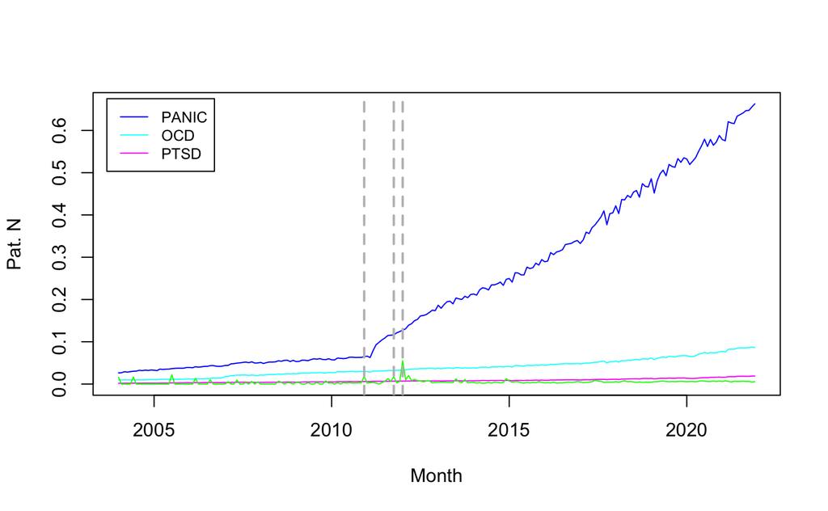

```r
lines(google.ts/100*max(inciNEURO4_3.ts[,1]),col="green")
# Add vertical lines indicating date of celerbity disclosures
abline(v=c(2004+(which(data$googCha == 100)-1)/120*10,2004+(which(data$googKim == 100)-1)/120*10,2004+(which(data$googLee == 100)-1)/120*10), col="gray", lty="dashed", lwd=2)
```

```r
#dev.off()
```

Doing changing the inclusion criteria.

```r
prevNEURO3_3.ts=ts.union(prevPANIC3.ts, prevPTSD3.ts, prevOCD3.ts);
inciNEURO3_3.ts=ts.union(inciPANIC3.ts, inciPTSD3.ts, inciOCD3.ts);
#jpeg(file="~/Dropbox/gitLab/studyDepressionBigData/prevNEURO3_3.jpeg")
plot(prevNEURO3_3.ts, type="l", plot.type="s", col=c("blue","magenta","cyan"), xlab="Month", ylab="Pat. N", linetype=c("solid","dashed"), ylim=c(0,max(prevNEURO3_3.ts[,1])))
legend("topleft", inset = 0.02, legend=c("PANIC","OCD", "PTSD"),
       col=c("blue", "cyan","magenta"), lty=1, cex=0.8)
#lines(google.ts/100*max(prevNEURO3.ts[,1]),col="green")
# Add vertical lines indicating date of celerbity disclosures
abline(v=c(2004+(which(data$googCha == 100)-1)/120*10,2004+(which(data$googKim == 100)-1)/120*10,2004+(which(data$googLee == 100)-1)/120*10), col="gray", lty="dashed", lwd=2)
#dev.off()
```

```r
prevNEURO2_3.ts=ts.union(prevPANIC2.ts, prevPTSD2.ts, prevOCD2.ts);
inciNEURO2_3.ts=ts.union(inciPANIC2.ts, inciPTSD2.ts, inciOCD2.ts);
#jpeg(file="~/Dropbox/gitLab/studyDepressionBigData/prevNEURO2_3.jpeg")
plot(prevNEURO2_3.ts, type="l", plot.type="s", col=c("blue","magenta","cyan"), xlab="Month", ylab="Pat. N", linetype=c("solid","dashed"), ylim=c(0,max(prevNEURO2_3.ts[,1])))
legend("topleft", inset = 0.02, legend=c("PANIC","OCD", "PTSD"),
       col=c("blue", "cyan","magenta"), lty=1, cex=0.8)
#lines(google.ts/100*max(prevNEURO3.ts[,1]),col="green")
# Add vertical lines indicating date of celerbity disclosures
abline(v=c(2004+(which(data$googCha == 100)-1)/120*10,2004+(which(data$googKim == 100)-1)/120*10,2004+(which(data$googLee == 100)-1)/120*10), col="gray", lty="dashed", lwd=2)
#dev.off()
```

```r
prevNEURO1_3.ts=ts.union(prevPANIC1.ts, prevPTSD1.ts, prevOCD1.ts);
inciNEURO1_3.ts=ts.union(inciPANIC1.ts, inciPTSD1.ts, inciOCD1.ts);
#jpeg(file="~/Dropbox/gitLab/studyDepressionBigData/prevNEURO1_3.jpeg")
plot(prevNEURO1_3.ts, type="l", plot.type="s", col=c("blue","magenta","cyan"), xlab="Month", ylab="Pat. N", linetype=c("solid","dashed"), ylim=c(0,max(prevNEURO1_3.ts[,1])))
legend("topleft", inset = 0.02, legend=c("PANIC","OCD", "PTSD"),
       col=c("blue", "cyan","magenta"), lty=1, cex=0.8)
#lines(google.ts/100*max(prevNEURO3.ts[,1]),col="green")
# Add vertical lines indicating date of celerbity disclosures
abline(v=c(2004+(which(data$googCha == 100)-1)/120*10,2004+(which(data$googKim == 100)-1)/120*10,2004+(which(data$googLee == 100)-1)/120*10), col="gray", lty="dashed", lwd=2)
#dev.off()
```

# PREVALENCE ALL

```r
prevPANIC1234_OCD4.ts=ts.union(prevPANIC4.ts, prevPANIC3.ts, prevPANIC2.ts, prevPANIC1.ts,prevOCD4.ts);
#jpeg(file="~/Dropbox/gitLab/studyDepressionBigData/prevPANIC1234_OCD4.jpeg")
plot(prevPANIC1234_OCD4.ts, type="l", plot.type="s", col=c("blue4", "blue3","blue2","blue","magenta"), xlab="Month", ylab="Pat. %", linetype=c("solid","dashed"), ylim=c(0,max(prevNEURO4_3.ts[,1])))
legend("topleft", inset = 0.02, legend=c("PANIC4","PANIC3", "PANIC2", "PANIC1","OCD4"),
       col=c("blue4", "blue3","blue2","blue","magenta"), lty=1, cex=0.8)
```

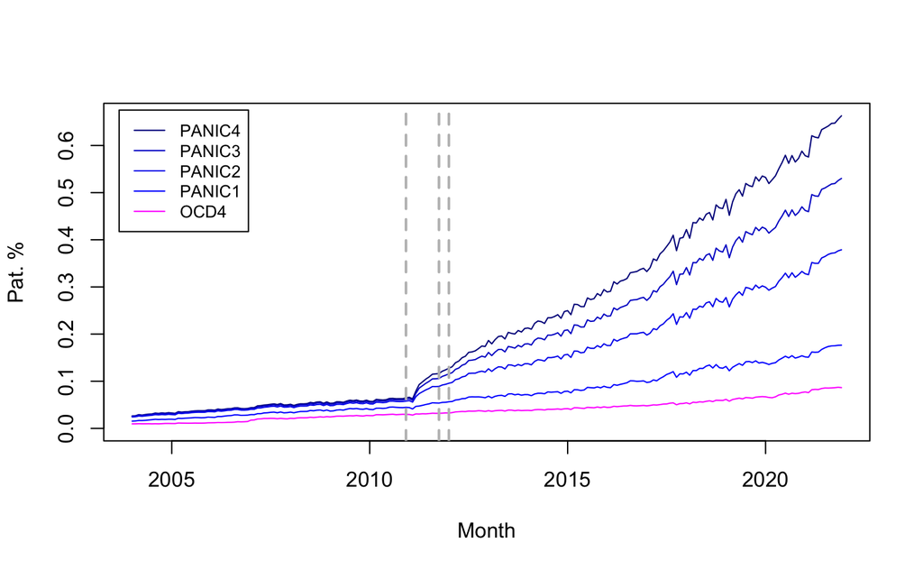

```r
#lines(google.ts/100*max(prevNEURO3.ts[,1]),col="green")
# Add vertical lines indicating date of celerbity disclosures
abline(v=c(2004+(which(data$googCha == 100)-1)/120*10,2004+(which(data$googKim == 100)-1)/120*10,2004+(which(data$googLee == 100)-1)/120*10), col="gray", lty="dashed", lwd=2)
```

```r
#dev.off()
```

# INCIDENCE ALL

```r
inciPANIC1234_OCD1234.ts=ts.union(inciPANIC4.ts, inciPANIC3.ts, inciPANIC2.ts, inciPANIC1.ts,inciOCD4.ts,inciOCD3.ts,inciOCD2.ts,inciOCD1.ts);
#jpeg(file="~/Dropbox/gitLab/studyDepressionBigData/inciPANIC1234_OCD1234.jpeg")
plot(inciPANIC1234_OCD1234.ts, type="l", plot.type="s", col=c("blue4", "blue3","blue2","blue","darkorchid4","darkorchid3","darkorchid2","darkorchid1"), xlab="Month", ylab="New Pat. %", linetype=c("solid","dashed"), ylim=c(0,max(inciPANIC1234_OCD1234.ts[,1])))
legend("topleft", inset = 0.02, legend=c("PANIC4","PANIC3", "PANIC2", "PANIC1","OCD4","OCD3","OCD2","OCD1"),
       col=c("blue4", "blue3","blue2","blue","darkorchid4","darkorchid3","darkorchid2","darkorchid1"), lty=1, cex=0.8)
```

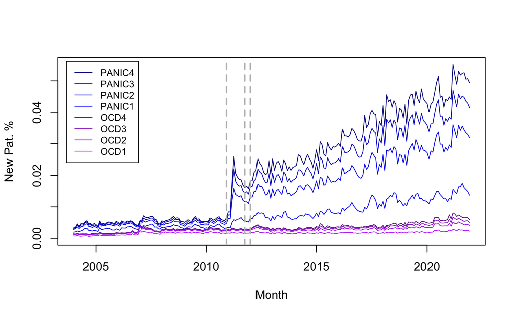

```r
#lines(google.ts/100*max(prevNEURO3.ts[,1]),col="green")
# Add vertical lines indicating date of celerbity disclosures
abline(v=c(2004+(which(data$googCha == 100)-1)/120*10,2004+(which(data$googKim == 100)-1)/120*10,2004+(which(data$googLee == 100)-1)/120*10), col="gray", lty="dashed", lwd=2)
```

```r
#dev.off()
```

# PREVALENCE ALL PANIC OCD

```r
prevPANIC1234_OCD1234.ts=ts.union(prevPANIC4.ts, prevPANIC3.ts, prevPANIC2.ts, prevPANIC1.ts,prevOCD4.ts,prevOCD3.ts,prevOCD2.ts,prevOCD1.ts);
#jpeg(file="~/Dropbox/gitLab/studyDepressionBigData/prevPANIC1234_OCD1234.jpeg")
plot(prevPANIC1234_OCD1234.ts, type="l", plot.type="s", col=c("blue4", "blue3","blue2","blue","darkorchid4","darkorchid3","darkorchid2","darkorchid1"), xlab="Month", ylab="New Pat. %", linetype=c("solid","dashed"), ylim=c(0,max(prevPANIC1234_OCD1234.ts[,1])))
legend("topleft", inset = 0.02, legend=c("PANIC4","PANIC3", "PANIC2", "PANIC1","OCD4","OCD3","OCD2","OCD1"),
       col=c("blue4", "blue3","blue2","blue","darkorchid4","darkorchid3","darkorchid2","darkorchid1"), lty=1, cex=0.8)
```

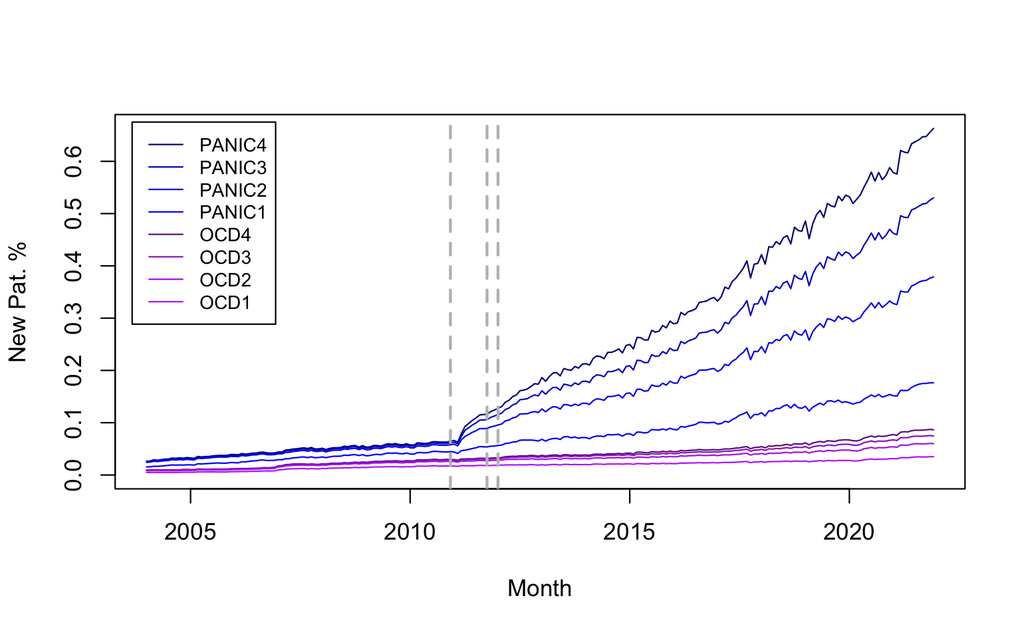

```r
#lines(google.ts/100*max(prevNEURO3.ts[,1]),col="green")
# Add vertical lines indicating date of celerbity disclosures
abline(v=c(2004+(which(data$googCha == 100)-1)/120*10,2004+(which(data$googKim == 100)-1)/120*10,2004+(which(data$googLee == 100)-1)/120*10), col="gray", lty="dashed", lwd=2)
```

```r
#dev.off()
```

# Draw graph of incidence and google data

```r
inciNEURO3.ts=ts.union(inciPANIC.ts, inciPTSD.ts, inciOCD.ts);
#pdf(file="~/Dropbox/gitLab/studyDepressionBigData/inciNEURO320042021.pdf")
plot(inciNEURO3.ts, type="l", plot.type="s", col=c("blue","magenta","cyan"), xlab="Month", ylab="Pat. N", linetype=c("solid","dashed"), ylim=c(0,max(inciPANIC.ts)))
legend("topleft", inset = 0.02, legend=c("PANIC","OCD", "PTSD"),
       col=c("blue", "cyan","magenta"), lty=1, cex=0.8)
```

```r
polygon(c(min(index(google.ts)),index(google.ts), max(index(google.ts))), c(0, google.ts*max(inciPANIC.ts)/100,0),col="blue")
polygon(c(min(index(googleOCDrelative.ts)),index(googleOCDrelative.ts), max(index(googleOCDrelative.ts))), c(0, googleOCDrelative.ts*max(inciPANIC.ts)/100,0),col="green")
```

[figure not shown]

```r
# Add vertical lines indicating date of celerbity disclosures
abline(v=c(2004+(which(data$googCha == 100)-1)/120*10,2004+(which(data$googKim == 100)-1)/120*10,2004+(which(data$googLee == 100)-1)/120*10), col="gray", lty="dashed", lwd=2)
```

```r
#dev.off()
```

```r
# check autocorrelation
acf2(inciPANIC4.ts, max.lag=24)
# View ACF/PACF plots of differenced/seasonally differenced data
acf2(diff(inciPANIC4.ts,lag=12), max.lag=24)
acf2(diff(diff(inciPANIC4.ts,lag=12)), max.lag=24)
```

transferF.ts is the time series of transfer function from the celebrities’ disclosures.

# make transfer fuction matrix

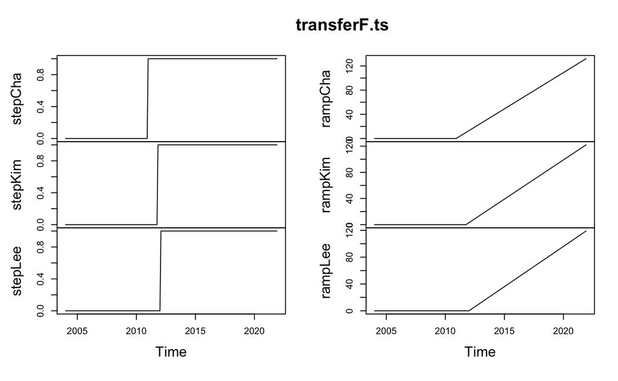

```r
countN=1:216;
monthCha=which(data$googCha == 100);
monthKim=which(data$googKim == 100);
monthLee=which(data$googLee == 100);

stepCha = as.numeric(countN > monthCha)
stepKim = as.numeric(countN > monthKim)
stepLee = as.numeric(countN > monthLee)
rampCha <- append(rep(0,monthCha), seq(1,216-monthCha,1))
rampKim <- append(rep(0,monthKim), seq(1,216-monthKim,1))
rampLee <- append(rep(0,monthLee), seq(1,216-monthLee,1))
transferF=cbind(stepCha,stepKim,stepLee,rampCha,rampKim,rampLee)
transferF.ts=ts(transferF,frequency=12, start=c(2004,1))
transferFGoogle=as.numeric(google.ts)
transferFGoogle.ts=ts(transferF,frequency=12, start=c(2004,1))

plot(transferF.ts)
```

```r
# model 1 is for statistical analysis result is (1 0 0) , (0,0,1)
incimodel1 <- auto.arima(inciPANIC1.ts, seasonal=TRUE, xreg=transferF, max.d=3, max.D=3, stepwise=FALSE, trace=TRUE);
# Check residuals
checkresiduals(incimodel1)
Box.test(incimodel1$residuals, lag = 24, type = "Ljung-Box")
# Estimate parameters and confidence intervals
summary(incimodel1)
confint(incimodel1)
coeftest(incimodel1)
```

```r
# model 1 is for statistical analysis result is (1 0 0) , (0,0,1)
incimodel2 <- auto.arima(inciPANIC2.ts, seasonal=TRUE, xreg=transferF, max.d=3, max.D=3, stepwise=FALSE, trace=TRUE);
# Check residuals
checkresiduals(incimodel2)
Box.test(incimodel2$residuals, lag = 24, type = "Ljung-Box")
# Estimate parameters and confidence intervals
summary(incimodel2)
confint(incimodel2)
coeftest(incimodel2)
```

```r
# model 1 is for statistical analysis result is (1 0 0) , (0,0,1)
incimodel3 <- auto.arima(inciPANIC3.ts, seasonal=TRUE, xreg=transferF, max.d=3, max.D=3, stepwise=FALSE, trace=TRUE);
# Check residuals
checkresiduals(incimodel3)
Box.test(incimodel3$residuals, lag = 24, type = "Ljung-Box")
# Estimate parameters and confidence intervals
summary(incimodel3)
confint(incimodel3)
coeftest(incimodel3)
```

Below is the selected model of incidence. In the text:Only the first celebrity disclosure significantly increased both the level (0·0058%, 95% CI: 0·0022%–0·0095%, p < 0·005) and slope of the monthly incidence of panic disorder (0·00078% per month, 95% CI 0·00019%–0·0014% per month, p < 0·01).

```r
# model 1 is for statistical analysis result is (1 0 0) , (0,0,1)
incimodel4 <- auto.arima(inciPANIC4.ts, seasonal=TRUE, xreg=transferF, max.d=3, max.D=3, stepwise=FALSE, trace=TRUE);
```

```
 Fitting models using approximations to speed things up...

 Regression with ARIMA(0,0,0)            errors : -1744.304
 Regression with ARIMA(0,0,0)            errors : -1985.792
 Regression with ARIMA(0,0,0)(0,0,1)[12] errors : -1858.405
 Regression with ARIMA(0,0,0)(0,0,1)[12] errors : Inf
 Regression with ARIMA(0,0,0)(0,0,2)[12] errors : Inf
 Regression with ARIMA(0,0,0)(0,0,2)[12] errors : Inf
 Regression with ARIMA(0,0,0)(1,0,0)[12] errors : -1959.339
 Regression with ARIMA(0,0,0)(1,0,0)[12] errors : -2008.507
 Regression with ARIMA(0,0,0)(1,0,1)[12] errors : Inf
 Regression with ARIMA(0,0,0)(1,0,1)[12] errors : Inf
 Regression with ARIMA(0,0,0)(1,0,2)[12] errors : Inf
 Regression with ARIMA(0,0,0)(1,0,2)[12] errors : Inf
 Regression with ARIMA(0,0,0)(2,0,0)[12] errors : Inf
 Regression with ARIMA(0,0,0)(2,0,0)[12] errors : -1994.217
 Regression with ARIMA(0,0,0)(2,0,1)[12] errors : Inf
 Regression with ARIMA(0,0,0)(2,0,1)[12] errors : Inf
 Regression with ARIMA(0,0,0)(2,0,2)[12] errors : Inf
 Regression with ARIMA(0,0,0)(2,0,2)[12] errors : Inf
 Regression with ARIMA(0,0,1)            errors : -1847.789
 Regression with ARIMA(0,0,1)            errors : -2010.496
 Regression with ARIMA(0,0,1)(0,0,1)[12] errors : -1932.638
 Regression with ARIMA(0,0,1)(0,0,1)[12] errors : Inf
 Regression with ARIMA(0,0,1)(0,0,2)[12] errors : -1939.038
 Regression with ARIMA(0,0,1)(0,0,2)[12] errors : Inf
 Regression with ARIMA(0,0,1)(1,0,0)[12] errors : -1988.242
 Regression with ARIMA(0,0,1)(1,0,0)[12] errors : Inf
 Regression with ARIMA(0,0,1)(1,0,1)[12] errors : Inf
 Regression with ARIMA(0,0,1)(1,0,1)[12] errors : Inf
 Regression with ARIMA(0,0,1)(1,0,2)[12] errors : Inf
 Regression with ARIMA(0,0,1)(1,0,2)[12] errors : Inf
 Regression with ARIMA(0,0,1)(2,0,0)[12] errors : -1988.01
 Regression with ARIMA(0,0,1)(2,0,0)[12] errors : -2018.107
 Regression with ARIMA(0,0,1)(2,0,1)[12] errors : Inf
 Regression with ARIMA(0,0,1)(2,0,1)[12] errors : Inf
 Regression with ARIMA(0,0,1)(2,0,2)[12] errors : Inf
 Regression with ARIMA(0,0,1)(2,0,2)[12] errors : Inf
 Regression with ARIMA(0,0,2)            errors : -1903.597
 Regression with ARIMA(0,0,2)            errors : -2019.842
```

[output cut: 146 more lines]

```
 Regression with ARIMA(4,0,0)(0,0,1)[12] errors : -2011.971
 Regression with ARIMA(4,0,0)(0,0,1)[12] errors : Inf
 Regression with ARIMA(4,0,0)(1,0,0)[12] errors : -2006.8
 Regression with ARIMA(4,0,0)(1,0,0)[12] errors : Inf
 Regression with ARIMA(4,0,1)            errors : Inf
 Regression with ARIMA(4,0,1)            errors : -2016.639
 Regression with ARIMA(5,0,0)            errors : -1982.65
 Regression with ARIMA(5,0,0)            errors : -2019.662

 Now re-fitting the best model(s) without approximations...




 Best model: Regression with ARIMA(1,0,0)(0,0,1)[12] errors
```

```
    Ljung-Box test

data:  Residuals from Regression with ARIMA(1,0,0)(0,0,1)[12] errors
Q* = 20.216, df = 22, p-value = 0.5695

Model df: 2.   Total lags used: 24
```

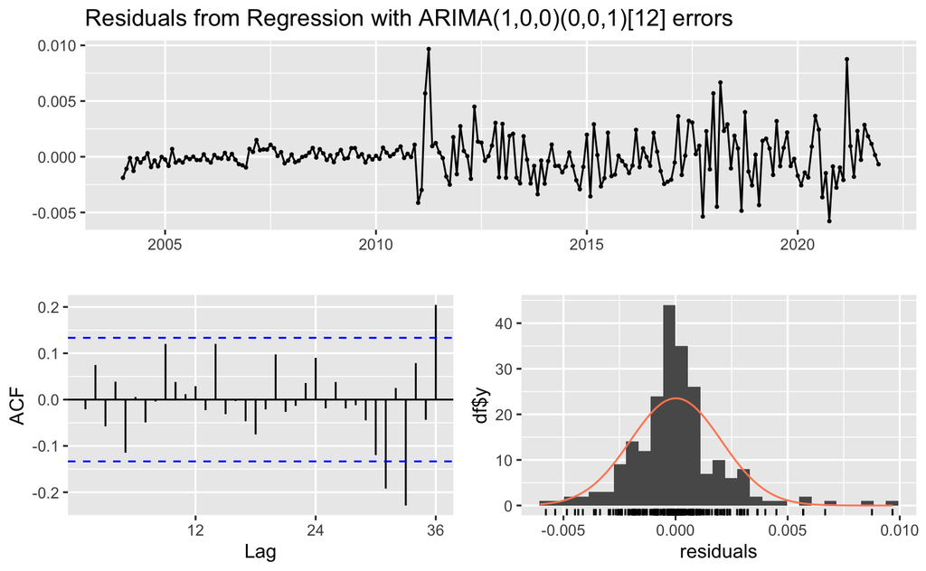

```r
# Check residuals
checkresiduals(incimodel4)
```

```r
Box.test(incimodel4$residuals, lag = 24, type = "Ljung-Box")
```

```
    Box-Ljung test

data:  incimodel4$residuals
X-squared = 20.216, df = 24, p-value = 0.6844
```

```r
# Estimate parameters and confidence intervals
summary(incimodel4)
```

```
Series: inciPANIC4.ts
Regression with ARIMA(1,0,0)(0,0,1)[12] errors

Coefficients:
         ar1    sma1  intercept  stepCha  stepKim  stepLee  rampCha  rampKim  rampLee
      0.3953  0.3734     0.0055   0.0058  -0.0039    8e-04    8e-04  -0.0001  -0.0004
s.e.  0.0662  0.1349     0.0005   0.0019   0.0030    2e-03    3e-04   0.0015   0.0013

sigma^2 = 4.25e-06:  log likelihood = 1032.92
AIC=-2045.84   AICc=-2044.77   BIC=-2012.09

Training set error measures:
                       ME        RMSE         MAE       MPE    MAPE      MASE        ACF1
Training set 1.431561e-05 0.002018219 0.001366502 -1.071599 7.48214 0.4412333 -0.02085657
```

```r
confint(incimodel4)
```

```
                  2.5 %      97.5 %
ar1        0.2654833297 0.525096436
sma1       0.1090416417 0.637782250
intercept  0.0045494745 0.006443885
stepCha    0.0021693392 0.009495776
stepKim   -0.0096708467 0.001970305
stepLee   -0.0030503483 0.004735527
rampCha    0.0001911517 0.001369437
rampKim   -0.0029191621 0.002799575
rampLee   -0.0030324226 0.002144572
```

```r
coeftest(incimodel4)
```

```
z test of coefficients:

             Estimate  Std. Error z value  Pr(>|z|)
ar1        3.9529e-01  6.6229e-02  5.9685 2.394e-09 ***
sma1       3.7341e-01  1.3489e-01  2.7684  0.005634 **
intercept  5.4967e-03  4.8328e-04 11.3738 < 2.2e-16 ***
stepCha    5.8326e-03  1.8690e-03  3.1206  0.001805 **
stepKim   -3.8503e-03  2.9697e-03 -1.2965  0.194802
stepLee    8.4259e-04  1.9862e-03  0.4242  0.671409
rampCha    7.8029e-04  3.0059e-04  2.5959  0.009435 **
rampKim   -5.9794e-05  1.4589e-03 -0.0410  0.967307
rampLee   -4.4393e-04  1.3207e-03 -0.3361  0.736771
---
Signif. codes:  0 ‘***’ 0.001 ‘**’ 0.01 ‘*’ 0.05 ‘.’ 0.1 ‘ ’ 1
```

# OCD model

```r
# model 1 is for statistical analysis result is (1 0 0) , (0,0,1)
modelOCD4 <- auto.arima(inciOCD4.ts, seasonal=TRUE, xreg=transferF, max.d=3, max.D=3, stepwise=FALSE, trace=TRUE);
# Check residuals
checkresiduals(modelOCD4)
Box.test(modelOCD4$residuals, lag = 24, type = "Ljung-Box")
# Estimate parameters and confidence intervals
summary(modelOCD4)
confint(modelOCD4)
coeftest(modelOCD4)
```

Significance was found in two cases:grangertest(diff(prevPANIC4.ts) ~ google.ts[-216], order=2) and grangertest(diff(prevPANIC4.ts) ~ google.ts[-216], order=3). A significant p-value in the context of the ADF test suggests that the time series is likely stationary. A significant p-value was found in google.ts and diff(prevPANIC4.ts) diff(inciPANIC4.ts). In the manuscript: The monthly incidence and prevalence were nonstationary (ADF = -2·98, p = 0·17 and ADF = -0·73, p = 0·97 for incidence and prevalence, respectively); the first-order differences in the monthly incidence and prevalence of panic disorder were stationary (ADF = -8·19, p < 0·05 and ADF = -7·14, p < 0·05 for incidence and prevalence, respectively).

# correlation between Google trend and incidence

```r
library(tseries)
adf.test(google.ts, alternative = "stationary")
```

```
    Augmented Dickey-Fuller Test

data:  google.ts
Dickey-Fuller = -4.1402, Lag order = 5, p-value = 0.01
alternative hypothesis: stationary
```

```r
adf.test(inciPANIC4.ts, alternative = "stationary")
```

```
    Augmented Dickey-Fuller Test

data:  inciPANIC4.ts
Dickey-Fuller = -2.9771, Lag order = 5, p-value = 0.1661
alternative hypothesis: stationary
```

```r
adf.test(prevPANIC4.ts, alternative = "stationary")
```

```
    Augmented Dickey-Fuller Test

data:  prevPANIC4.ts
Dickey-Fuller = -0.72732, Lag order = 5, p-value = 0.9668
alternative hypothesis: stationary
```

```r
#adf.test(inciPANIC3.ts, alternative = "stationary")
#adf.test(prevPANIC3.ts, alternative = "stationary")

#adf.test(inciPANIC2.ts, alternative = "stationary")
#adf.test(prevPANIC2.ts, alternative = "stationary")

#adf.test(inciPANIC1.ts, alternative = "stationary")
#adf.test(prevPANIC1.ts, alternative = "stationary")

adf.test(diff(inciPANIC4.ts), alternative = "stationary")
```

```
    Augmented Dickey-Fuller Test

data:  diff(inciPANIC4.ts)
Dickey-Fuller = -8.1899, Lag order = 5, p-value = 0.01
alternative hypothesis: stationary
```

```r
adf.test(diff(prevPANIC4.ts), alternative = "stationary")
```

```
    Augmented Dickey-Fuller Test

data:  diff(prevPANIC4.ts)
Dickey-Fuller = -7.1425, Lag order = 5, p-value = 0.01
alternative hypothesis: stationary
```

```r
#adf.test(diff(inciPANIC3.ts), alternative = "stationary")
#adf.test(diff(prevPANIC3.ts), alternative = "stationary")

#adf.test(diff(inciPANIC2.ts), alternative = "stationary")
#adf.test(diff(prevPANIC2.ts), alternative = "stationary")

#adf.test(diff(inciPANIC1.ts), alternative = "stationary")
#adf.test(diff(prevPANIC1.ts), alternative = "stationary")


#cor.test(inciPANIC1.ts, google.ts,  method="kendall")
cor.test(diff(inciPANIC4.ts), google.ts[-216],  method="spearman", exact=FALSE)
```

```
    Spearman's rank correlation rho

data:  diff(inciPANIC4.ts) and google.ts[-216]
S = 1647882, p-value = 0.9405
alternative hypothesis: true rho is not equal to 0
sample estimates:
        rho
0.005118754
```

```r
cor.test(diff(prevPANIC4.ts), google.ts[-216],  method="spearman", exact=FALSE)
```

```
    Spearman's rank correlation rho

data:  diff(prevPANIC4.ts) and google.ts[-216]
S = 1342497, p-value = 0.005311
alternative hypothesis: true rho is not equal to 0
sample estimates:
      rho
0.1894897
```

```r
#cor.test(diff(inciPANIC3.ts), google.ts[-216],  method="spearman", exact=FALSE)
#cor.test(diff(prevPANIC3.ts), google.ts[-216],  method="spearman", exact=FALSE)

#cor.test(diff(inciPANIC2.ts), google.ts[-216],  method="spearman", exact=FALSE)
#cor.test(diff(prevPANIC2.ts), google.ts[-216],  method="spearman", exact=FALSE)

#cor.test(diff(inciPANIC1.ts), google.ts[-216],  method="spearman", exact=FALSE)
#cor.test(diff(prevPANIC1.ts), google.ts[-216],  method="spearman", exact=FALSE)

grangertest(diff(prevPANIC4.ts) ~ google.ts[-216], order=4)
```

```
Granger causality test

Model 1: diff(prevPANIC4.ts) ~ Lags(diff(prevPANIC4.ts), 1:4) + Lags(google.ts[-216], 1:4)
Model 2: diff(prevPANIC4.ts) ~ Lags(diff(prevPANIC4.ts), 1:4)
  Res.Df Df      F  Pr(>F)
1    202
2    206 -4 1.9743 0.09979 .
---
Signif. codes:  0 ‘***’ 0.001 ‘**’ 0.01 ‘*’ 0.05 ‘.’ 0.1 ‘ ’ 1
```

```r
grangertest(google.ts[-216] ~ diff(prevPANIC4.ts), order=4)
```

```
Granger causality test

Model 1: google.ts[-216] ~ Lags(google.ts[-216], 1:4) + Lags(diff(prevPANIC4.ts), 1:4)
Model 2: google.ts[-216] ~ Lags(google.ts[-216], 1:4)
  Res.Df Df      F Pr(>F)
1    202
2    206 -4 0.7346 0.5694
```

```r
#grangertest(inciPANIC1.ts ~ google.ts, order=3)
#grangertest(inciPANIC1.ts ~ google.ts, order=2)
#grangertest(inciPANIC1.ts ~ google.ts, order=1)

grangertest(diff(prevPANIC4.ts) ~ google.ts[-216], order=3)
```

```
Granger causality test

Model 1: diff(prevPANIC4.ts) ~ Lags(diff(prevPANIC4.ts), 1:3) + Lags(google.ts[-216], 1:3)
Model 2: diff(prevPANIC4.ts) ~ Lags(diff(prevPANIC4.ts), 1:3)
  Res.Df Df      F  Pr(>F)
1    205
2    208 -3 3.1082 0.02748 *
---
Signif. codes:  0 ‘***’ 0.001 ‘**’ 0.01 ‘*’ 0.05 ‘.’ 0.1 ‘ ’ 1
```

```r
#grangertest(diff(prevPANIC1.ts) ~ google.ts[-216], order=3)
grangertest(diff(prevPANIC4.ts) ~ google.ts[-216], order=2)
```

```
Granger causality test

Model 1: diff(prevPANIC4.ts) ~ Lags(diff(prevPANIC4.ts), 1:2) + Lags(google.ts[-216], 1:2)
Model 2: diff(prevPANIC4.ts) ~ Lags(diff(prevPANIC4.ts), 1:2)
  Res.Df Df      F  Pr(>F)
1    208
2    210 -2 4.2575 0.01541 *
---
Signif. codes:  0 ‘***’ 0.001 ‘**’ 0.01 ‘*’ 0.05 ‘.’ 0.1 ‘ ’ 1
```

```r
#grangertest(diff(prevPANIC1.ts) ~ google.ts[-216], order=2)
grangertest(diff(prevPANIC4.ts) ~ google.ts[-216], order=1)
```

```
Granger causality test

Model 1: diff(prevPANIC4.ts) ~ Lags(diff(prevPANIC4.ts), 1:1) + Lags(google.ts[-216], 1:1)
Model 2: diff(prevPANIC4.ts) ~ Lags(diff(prevPANIC4.ts), 1:1)
  Res.Df Df      F Pr(>F)
1    211
2    212 -1 2.4692 0.1176
```

```r
#grangertest(diff(prevPANIC1.ts) ~ google.ts[-216], order=1)

grangertest(google.ts[-216] ~ diff(prevPANIC4.ts), order=3)
```

```
Granger causality test

Model 1: google.ts[-216] ~ Lags(google.ts[-216], 1:3) + Lags(diff(prevPANIC4.ts), 1:3)
Model 2: google.ts[-216] ~ Lags(google.ts[-216], 1:3)
  Res.Df Df      F Pr(>F)
1    205
2    208 -3 0.9343  0.425
```

```r
grangertest(diff(prevPANIC4.ts) ~ google.ts[-216], order=2)
```

```
Granger causality test

Model 1: diff(prevPANIC4.ts) ~ Lags(diff(prevPANIC4.ts), 1:2) + Lags(google.ts[-216], 1:2)
Model 2: diff(prevPANIC4.ts) ~ Lags(diff(prevPANIC4.ts), 1:2)
  Res.Df Df      F  Pr(>F)
1    208
2    210 -2 4.2575 0.01541 *
---
Signif. codes:  0 ‘***’ 0.001 ‘**’ 0.01 ‘*’ 0.05 ‘.’ 0.1 ‘ ’ 1
```

```r
grangertest(google.ts[-216] ~ diff(prevPANIC4.ts), order=2)
```

```
Granger causality test

Model 1: google.ts[-216] ~ Lags(google.ts[-216], 1:2) + Lags(diff(prevPANIC4.ts), 1:2)
Model 2: google.ts[-216] ~ Lags(google.ts[-216], 1:2)
  Res.Df Df      F Pr(>F)
1    208
2    210 -2 1.3733 0.2556
```

```r
grangertest(diff(prevPANIC4.ts) ~ google.ts[-216], order=1)
```

```
Granger causality test

Model 1: diff(prevPANIC4.ts) ~ Lags(diff(prevPANIC4.ts), 1:1) + Lags(google.ts[-216], 1:1)
Model 2: diff(prevPANIC4.ts) ~ Lags(diff(prevPANIC4.ts), 1:1)
  Res.Df Df      F Pr(>F)
1    211
2    212 -1 2.4692 0.1176
```

```r
grangertest(google.ts[-216] ~ diff(prevPANIC4.ts), order=1)
```

```
Granger causality test

Model 1: google.ts[-216] ~ Lags(google.ts[-216], 1:1) + Lags(diff(prevPANIC4.ts), 1:1)
Model 2: google.ts[-216] ~ Lags(google.ts[-216], 1:1)
  Res.Df Df      F Pr(>F)
1    211
2    212 -1 2.0554 0.1532
```

```r
grangertest(diff(inciPANIC4.ts) ~ google.ts[-216], order=1)
```

```
Granger causality test

Model 1: diff(inciPANIC4.ts) ~ Lags(diff(inciPANIC4.ts), 1:1) + Lags(google.ts[-216], 1:1)
Model 2: diff(inciPANIC4.ts) ~ Lags(diff(inciPANIC4.ts), 1:1)
  Res.Df Df      F Pr(>F)
1    211
2    212 -1 0.2089 0.6481
```

```r
grangertest(google.ts[-216] ~ diff(inciPANIC4.ts), order=1)
```

```
Granger causality test

Model 1: google.ts[-216] ~ Lags(google.ts[-216], 1:1) + Lags(diff(inciPANIC4.ts), 1:1)
Model 2: google.ts[-216] ~ Lags(google.ts[-216], 1:1)
  Res.Df Df      F Pr(>F)
1    211
2    212 -1 2.1757 0.1417
```

```r
grangertest(diff(inciPANIC4.ts) ~ google.ts[-216], order=2)
```

```
Granger causality test

Model 1: diff(inciPANIC4.ts) ~ Lags(diff(inciPANIC4.ts), 1:2) + Lags(google.ts[-216], 1:2)
Model 2: diff(inciPANIC4.ts) ~ Lags(diff(inciPANIC4.ts), 1:2)
  Res.Df Df     F Pr(>F)
1    208
2    210 -2 0.748 0.4746
```

```r
grangertest(google.ts[-216] ~ diff(inciPANIC4.ts), order=2)
```

```
Granger causality test

Model 1: google.ts[-216] ~ Lags(google.ts[-216], 1:2) + Lags(diff(inciPANIC4.ts), 1:2)
Model 2: google.ts[-216] ~ Lags(google.ts[-216], 1:2)
  Res.Df Df      F Pr(>F)
1    208
2    210 -2 1.0948 0.3365
```

# influence of celebrities disclosures on Google search for panic disorder

```r
# model 1 is for statistical analysis result is (1 0 0) , (0,0,1)
modelG <- auto.arima(google.ts, seasonal=TRUE, xreg=transferF, max.d=3, max.D=3, stepwise=FALSE, trace=TRUE);
```

```
 Fitting models using approximations to speed things up...

 Regression with ARIMA(0,0,0)            errors : 1467.546
 Regression with ARIMA(0,0,0)            errors : 1438.37
 Regression with ARIMA(0,0,0)(0,0,1)[12] errors : 1469.671
 Regression with ARIMA(0,0,0)(0,0,1)[12] errors : 1436.105
 Regression with ARIMA(0,0,0)(0,0,2)[12] errors : 1470.464
 Regression with ARIMA(0,0,0)(0,0,2)[12] errors : 1437.554
 Regression with ARIMA(0,0,0)(1,0,0)[12] errors : 1443.065
 Regression with ARIMA(0,0,0)(1,0,0)[12] errors : 1410.607
 Regression with ARIMA(0,0,0)(1,0,1)[12] errors : 1445.24
 Regression with ARIMA(0,0,0)(1,0,1)[12] errors : 1412.668
 Regression with ARIMA(0,0,0)(1,0,2)[12] errors : 1445.291
 Regression with ARIMA(0,0,0)(1,0,2)[12] errors : 1414.447
 Regression with ARIMA(0,0,0)(2,0,0)[12] errors : 1413.224
 Regression with ARIMA(0,0,0)(2,0,0)[12] errors : 1378.516
 Regression with ARIMA(0,0,0)(2,0,1)[12] errors : 1415.268
 Regression with ARIMA(0,0,0)(2,0,1)[12] errors : 1380.582
 Regression with ARIMA(0,0,0)(2,0,2)[12] errors : 1416.469
 Regression with ARIMA(0,0,0)(2,0,2)[12] errors : 1382.168
 Regression with ARIMA(0,0,1)            errors : 1467.742
 Regression with ARIMA(0,0,1)            errors : 1440.523
 Regression with ARIMA(0,0,1)(0,0,1)[12] errors : 1469.417
 Regression with ARIMA(0,0,1)(0,0,1)[12] errors : 1438.236
 Regression with ARIMA(0,0,1)(0,0,2)[12] errors : 1470.248
 Regression with ARIMA(0,0,1)(0,0,2)[12] errors : 1439.764
 Regression with ARIMA(0,0,1)(1,0,0)[12] errors : 1441.615
 Regression with ARIMA(0,0,1)(1,0,0)[12] errors : 1412.389
 Regression with ARIMA(0,0,1)(1,0,1)[12] errors : 1443.726
 Regression with ARIMA(0,0,1)(1,0,1)[12] errors : 1414.539
 Regression with ARIMA(0,0,1)(1,0,2)[12] errors : 1444.441
 Regression with ARIMA(0,0,1)(1,0,2)[12] errors : 1416.378
 Regression with ARIMA(0,0,1)(2,0,0)[12] errors : 1410.987
 Regression with ARIMA(0,0,1)(2,0,0)[12] errors : 1380.322
 Regression with ARIMA(0,0,1)(2,0,1)[12] errors : 1413.157
 Regression with ARIMA(0,0,1)(2,0,1)[12] errors : 1382.459
 Regression with ARIMA(0,0,1)(2,0,2)[12] errors : 1414.155
 Regression with ARIMA(0,0,1)(2,0,2)[12] errors : 1383.938
 Regression with ARIMA(0,0,2)            errors : 1466.268
 Regression with ARIMA(0,0,2)            errors : 1442.444
```

[output cut: 146 more lines]

```
 Regression with ARIMA(4,0,0)(0,0,1)[12] errors : 1448.086
 Regression with ARIMA(4,0,0)(0,0,1)[12] errors : 1431.333
 Regression with ARIMA(4,0,0)(1,0,0)[12] errors : 1435.794
 Regression with ARIMA(4,0,0)(1,0,0)[12] errors : 1420.543
 Regression with ARIMA(4,0,1)            errors : 1439.011
 Regression with ARIMA(4,0,1)            errors : 1435.534
 Regression with ARIMA(5,0,0)            errors : 1443.767
 Regression with ARIMA(5,0,0)            errors : 1434.758

 Now re-fitting the best model(s) without approximations...




 Best model: Regression with ARIMA(3,0,0)(2,0,0)[12] errors
```

```
    Ljung-Box test

data:  Residuals from Regression with ARIMA(3,0,0)(2,0,0)[12] errors
Q* = 20.396, df = 19, p-value = 0.3711

Model df: 5.   Total lags used: 24
```

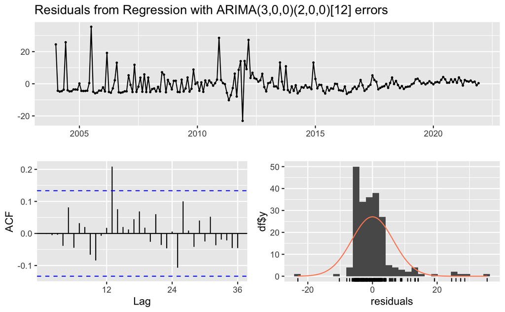

```r
# Check residuals
checkresiduals(modelG)
```

```r
Box.test(modelG$residuals, lag = 24, type = "Ljung-Box")
```

```
    Box-Ljung test

data:  modelG$residuals
X-squared = 20.396, df = 24, p-value = 0.674
```

```r
# Estimate parameters and confidence intervals
summary(modelG)
```

```
Series: google.ts
Regression with ARIMA(3,0,0)(2,0,0)[12] errors

Coefficients:
         ar1     ar2     ar3     sar1     sar2  intercept  stepCha   stepKim   stepLee  rampCha  rampKim   rampLee
      0.0125  0.0365  0.0321  -0.1731  -0.0878     4.0660  -4.7516  -77.2312  -76.7187   2.2823  44.6885  -46.9619
s.e.  0.0741  0.0855  0.0767   0.0821   0.0795     0.6344   4.8583   10.2900    7.1650   0.7359   4.6469    4.5899

sigma^2 = 43.45:  log likelihood = -707.9
AIC=1441.8   AICc=1443.6   BIC=1485.67

Training set error measures:
                      ME     RMSE      MAE MPE MAPE      MASE      ACF1
Training set 0.001323591 6.405829 4.114019 NaN  Inf 0.6834364 -0.001655
```

```r
confint(modelG)
```

```
                2.5 %       97.5 %
ar1        -0.1327339   0.15780815
ar2        -0.1310539   0.20402667
ar3        -0.1182962   0.18252982
sar1       -0.3341135  -0.01211718
sar2       -0.2436170   0.06797493
intercept   2.8227183   5.30937207
stepCha   -14.2738057   4.77053905
stepKim   -97.3992220 -57.06318322
stepLee   -90.7617197 -62.67561133
rampCha     0.8400070   3.72461748
rampKim    35.5806287  53.79627256
rampLee   -55.9580169 -37.96576789
```

```r
coeftest(modelG)
```

```
z test of coefficients:

            Estimate Std. Error  z value  Pr(>|z|)
ar1         0.012537   0.074119   0.1691  0.865680
ar2         0.036486   0.085481   0.4268  0.669500
ar3         0.032117   0.076743   0.4185  0.675582
sar1       -0.173115   0.082143  -2.1075  0.035076 *
sar2       -0.087821   0.079489  -1.1048  0.269239
intercept   4.066045   0.634362   6.4097 1.458e-10 ***
stepCha    -4.751633   4.858340  -0.9780  0.328056
stepKim   -77.231203  10.289995  -7.5055 6.121e-14 ***
stepLee   -76.718666   7.164955 -10.7075 < 2.2e-16 ***
rampCha     2.282312   0.735884   3.1015  0.001926 **
rampKim    44.688451   4.646933   9.6168 < 2.2e-16 ***
rampLee   -46.961892   4.589944 -10.2315 < 2.2e-16 ***
---
Signif. codes:  0 ‘***’ 0.001 ‘**’ 0.01 ‘*’ 0.05 ‘.’ 0.1 ‘ ’ 1
```

model0inci4 represents best fit model with its parameter using only pre-disclosure period. Best model: ARIMA(1,1,0)(1,0,0)[12]  
fmodel0inci4 means modeled time series using model0 fc0inci4 and fc0inci4.ts is the forecasted series using the fmodel0inci4 inciPANIC4.ts.2 .2 indicates combined time series with forecast

# Prediction model 1 : only using pre-disclosure period

```r
# model 0 is for prediction
model0inci4 <- auto.arima(window(inciPANIC4.ts, end=c(2010,12)), seasonal=TRUE, max.d=3, max.D=3, stepwise=FALSE, trace=TRUE);
fmodel0inci4 <- Arima(window(inciPANIC4.ts, end=c(2010,12)), order=c(1,1,0), seasonal=list(order=c(1,0,0), period=12))
fc0inci4 <- forecast(fmodel0inci4, h=(216-monthCha))
fc0inci4.ts <- ts(as.numeric(fc0inci4$mean), start=c(2011,1), frequency=12)
inciPANIC4.ts.2 <- ts.union(inciPANIC4.ts, fc0inci4.ts)

# for prevalence
# model 0 is for prediction
model0prev4 <- auto.arima(window(prevPANIC4.ts, end=c(2010,12)), seasonal=TRUE, max.d=3, max.D=3, stepwise=FALSE, trace=TRUE);
# ARIMA(0,1,4)(1,0,0)[12] with drift
fmodel0prev4 <- Arima(window(prevPANIC4.ts, end=c(2010,12)), order=c(0,1,4), seasonal=list(order=c(1,0,0), period=12))
fc0prev4 <- forecast(fmodel0prev4, h=(216-monthCha))
fc0prev4.ts <- ts(as.numeric(fc0prev4$mean), start=c(2011,1), frequency=12)
prevPANIC4.ts.2 <- ts.union(prevPANIC4.ts, fc0prev4.ts)
```

Due to the rounding of numbers, 0.6054839 was calculated 0.61 so 572.3712 % increase was presented as 577.78 % as following: The observed annual incidence of 0·61% in 2021 was an 577.77% higher than the predicted incidence of 0·09% (95% CI: -0·11%–0·29%).

Below one too:The observed annual prevalence of 7·53% in 2021 was a 775·58% higher than the forecasted incidence of 0·86% (95% CI:0·33%–1·40%).

```r
# forecast annual incidence in 2021 with 95% CI, supposing denominator-the number of total population does not vary across months
# CI lower upper is the second colums of fc0inci4$lower[,2] and
# forcast 2021 annual incidence
sum(tail(fc0inci4$mean,12))
# its CI 95%
sum(tail(fc0inci4$lower[,2],12))
sum(tail(fc0inci4$upper[,2],12))
# Percent increase of observed value from
(sum(tail(inciPANIC4.ts,12)) - sum(tail(fc0inci4$mean,12)))/sum(tail(fc0inci4$mean,12)) * 100


# forcast 2021 annual prevalence
sum(tail(fc0prev4$mean,12))
# its CI 95%
sum(tail(fc0prev4$lower[,2],12))
sum(tail(fc0prev4$upper[,2],12))
# Percent increase of observed value from
(sum(tail(prevPANIC4.ts,12)) - sum(tail(fc0prev4$mean,12)))/sum(tail(fc0prev4$mean,12)) * 100
# instead used one (7.53-0.86)*100/0.86 =775.58 %
```

Below is the raw material of Figure2.2.ai

```r
pdf(file="~/Dropbox/gitLab/studyDepressionBigData/inciPanicPrediction20042021_2.pdf")
plot(inciPANIC4.ts.2, type="l", plot.type="s", col=c('blue','deepskyblue'), xlab="Month", ylab="New Panic Pat. N", linetype=c("solid","dashed"), ylim=c(0,max(inciPANIC4.ts)))
# add confidence interval
tmp <- seq(from = 2011, to =2021.99, by = 1/12)
# below is drawing polygon supplying outline x,y coordinates
polygon(c(tmp,rev(tmp)),c(fc0inci4$lower[,2],rev(fc0inci4$upper[,2])), col=rgb(0, 0.75, 1,0.1), border = FALSE)
abline(v=c(2004+(which(data$googCha == 100)-1)/120*10,2004+(which(data$googKim == 100)-1)/120*10,2004+(which(data$googLee == 100)-1)/120*10), col="gray", lty="dashed", lwd=2)
dev.off()
```

```r
pdf(file="~/Dropbox/gitLab/studyDepressionBigData/prevPanicPrediction20042021_2.pdf")
plot(prevPANIC4.ts.2, type="l", plot.type="s", col=c('blue','deepskyblue'), xlab="Month", ylab="New Panic Pat. N", linetype=c("solid","dashed"), ylim=c(0,max(prevPANIC4.ts)))
```

```r
# add confidence interval
tmp <- seq(from = 2011, to =2021.99, by = 1/12)
# below is drawing polygon supplying outline x,y coordinates
polygon(c(tmp,rev(tmp)),c(fc0prev4$lower[,2],rev(fc0prev4$upper[,2])), col=rgb(0, 0.75, 1,0.1), border = FALSE)
abline(v=c(2004+(which(data$googCha == 100)-1)/120*10,2004+(which(data$googKim == 100)-1)/120*10,2004+(which(data$googLee == 100)-1)/120*10), col="gray", lty="dashed", lwd=2)
dev.off()
```

Below is applying the same procedure using inciPANIC1.ts, Best model: ARIMA(0,1,1)(2,1,0)[12]

```r
# model 1 is for prediction with primary only
model0inci1 <- auto.arima(window(inciPANIC1.ts, end=c(2010,12)), seasonal=TRUE, max.d=3, max.D=3, stepwise=FALSE, trace=TRUE);
fmodel0inci1 <- Arima(window(inciPANIC1.ts, end=c(2010,12)), order=c(0,1,1), seasonal=list(order=c(2,1,0), period=12))
incifc1 <- forecast(fmodel0inci1, h=(216-monthCha))
incifc1.ts <- ts(as.numeric(incifc1$mean), start=c(2011,1), frequency=12)
inciPANIC1.ts.2 <- ts.union(inciPANIC1.ts, incifc1.ts)
```

```r
#pdf(file="~/Dropbox/gitLab/studyDepressionBigData/inciPanicPrediction1.pdf")
plot(inciPANIC1.ts.2, type="l", plot.type="s", col=c('blue','deepskyblue'), xlab="Month", ylab="New Panic Pat. N", linetype=c("solid","dashed"), ylim=c(0,max(inciPANIC4.ts)))
# add confidence interval
tmp <- seq(from = 2011, to =2021.99, by = 1/12)
# below is drawing polygon supplying outline x,y coordinates
polygon(c(tmp,rev(tmp)),c(incifc1$lower[,2],rev(incifc1$upper[,2])), col=rgb(0, 0.75, 1,0.1), border = FALSE)
```

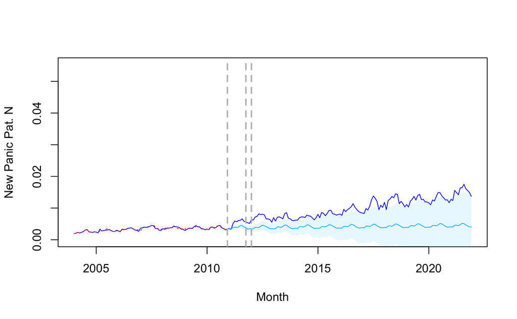

```r
abline(v=c(2004+(which(data$googCha == 100)-1)/120*10,2004+(which(data$googKim == 100)-1)/120*10,2004+(which(data$googLee == 100)-1)/120*10), col="gray", lty="dashed", lwd=2)
lines(fitted(fmodel0inci1),col="red",lwd=1, lty="dotted")
```

```r
#dev.off()
```

if we use the ARIMA MODEL of whole time series, best model was (1 0 0) (0 0 1), however, prediction should be done using only data by pre-disclosure period.

```r
# model 4 is for prediction with whole time series
incifmodel4 <- Arima(window(inciPANIC4.ts, end=c(2010,12)), order=c(1,0,0), seasonal=list(order=c(0,0,1), period=12))
incifc4 <- forecast(incifmodel4, h=(216-monthCha))
incifc4.ts <- ts(as.numeric(incifc4$mean), start=c(2011,1), frequency=12)
inciPANIC4.ts.1 <- ts.union(inciPANIC4.ts, incifc4.ts)
```

below is thus a wrong image

```r
#pdf(file="~/Dropbox/gitLab/studyDepressionBigData/inciPanicPrediction4.pdf")
plot(inciPANIC4.ts.1, type="l", plot.type="s", col=c('blue','deepskyblue'), xlab="Month", ylab="New Panic Pat. N", linetype=c("solid","dashed"), ylim=c(0,max(inciPANIC4.ts)))
# add confidence interval
tmp <- seq(from = 2011, to =2021.99, by = 1/12)
# below is drawing polygon supplying outline x,y coordinates
polygon(c(tmp,rev(tmp)),c(incifc4$lower[,2],rev(incifc4$upper[,2])), col=rgb(0, 0.75, 1,0.1), border = FALSE)
```

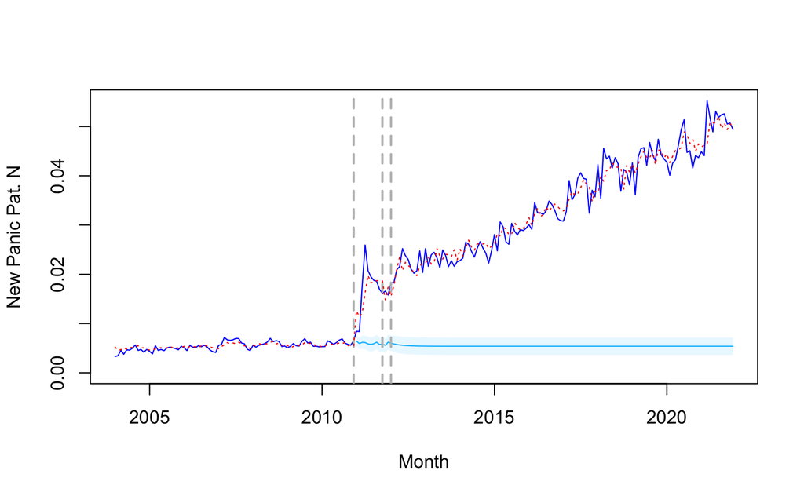

```r
abline(v=c(2004+(which(data$googCha == 100)-1)/120*10,2004+(which(data$googKim == 100)-1)/120*10,2004+(which(data$googLee == 100)-1)/120*10), col="gray", lty="dashed", lwd=2)
lines(fitted(incimodel4),col="red",lwd=1, lty="dotted")
```

```r
#dev.off()
```

Comparison of observed value, inciPANIC4.ts versus prediction values, fc0inci4. This is for the following contents of the manuscript: The monthly incidence of panic disorder was stable from January 2004 to December 2010 (0·0054 ± 0·00086%).

The trend of increasing incidence rates continued, reaching an annual rate of 0·61% in 2021. This represents an increase of 838·46% compared with the average annual incidence of 0·065% (± 0·0082%) recorded between 2004 and 2010.

… The observed monthly incidences were 35·48% (an observed monthly incidence of 0·0084% vs. the predicted 0·0062%, 95% CI:0·0053%–0·0072%), 33·33% (0·0084% vs. 0·0063%%, 95% CI:0·0052%–0·0075%), and 157·14% (0·018% vs. 0·0070%%, 95% CI:0·0055%–0·0084%) higher than the counterfactual predicted incidences for January 2011, February 2011, and March 2011, respectively.

# values case by case

```r
# incidence values during pre-disclosure period
# below is the monthly values of pre-disclosure period
mean(window(inciPANIC4.ts, start = c(2004, 1), end = c(2010, 12)))
sd(window(inciPANIC4.ts, start = c(2004, 1), end = c(2010, 12)))

#increase from December 2010 to January, February, March, April, 2011
# observed value on April 2011
valInci201104 <- window(inciPANIC4.ts, start = c(2011, 4), end = c(2011, 4))
(0.0084-0.0065)*100/0.0065
(0.018-0.0065)*100/0.0065

# for prevalence
valPrev201101 <- window(prevPANIC4.ts, start = c(2011, 1), end = c(2011, 1))


# observed value in 2021 = annual incidence in 2021
valInci2021 <- sum(window(inciPANIC4.ts, start = c(2021, 1), end = c(2021, 12)))
(0.026-0.0065)*100/0.0065

# observed value on January 2011
valInci201101 <- window(inciPANIC4.ts, start = c(2011, 1), end = c(2011, 1))
# predicted value on January 2011
valInci201101fc <- window(fc0inci4.ts, start = c(2011, 1), end = c(2011, 1))
#% increase
100*(0.0084-0.0062)/0.0062

# observed value on February 2011
valInci201102 <- window(inciPANIC4.ts, start = c(2011, 2), end = c(2011, 2))
# predicted value on February 2011
valInci201102fc <- window(fc0inci4.ts, start = c(2011, 2), end = c(2011, 2))
#% increase
100*(0.0084-0.0063)/0.0063

# observed value on March 2011
valInci201103 <- window(inciPANIC4.ts, start = c(2011, 3), end = c(2011, 3))
# predicted value on March 2011
valInci201103fc <- window(fc0inci4.ts, start = c(2011, 3), end = c(2011, 3))
#% increase
100*(0.018-0.0070)/0.0070

# for comparison with OCD, values of OCD were examined.
inciOCD4.ts


# belows seem not to be used in the manuscript: from the review at 20231219
mean(window(inciPANIC4.ts, end=c(2010,12)))
sd(window(inciPANIC4.ts, end=c(2010,12)))

# annual values
val201011 <- window(inciPANIC.ts, start = c(2010, 11), end = c(2010, 11))
as.numeric(val201011)
val201101 <- window(inciPANIC4.ts, start = c(2011, 1), end = c(2011, 1))
as.numeric(val201101)
val201102 <- window(inciPANIC.ts, start = c(2011, 2), end = c(2011, 2))
as.numeric(val201102)

# increase from Nov 2010 to Dec 2010 in percent
val201012 <- window(inciPANIC.ts, start = c(2010, 12), end = c(2010, 12))
as.numeric(val201012)/as.numeric(val201011)*100

# increase from Dec 2010 to Jan 2011 in percent
as.numeric(val201101)/as.numeric(val201012)*100

# increase from Dec 2010 to Feb 2011 in percent
as.numeric(val201102)/as.numeric(val201012)*100

# increase from Dec 2010 to march 2011 in percent
val201103 <- window(inciPANIC.ts, start = c(2011, 3), end = c(2011, 3))
as.numeric(val201103)/as.numeric(val201012)*100

as.numeric(val201101)/as.numeric(val201012)*100

# increase from Dec 2010 to April 2011 in percent
val201104 <- window(inciPANIC.ts, start = c(2011, 4), end = c(2011, 4))
as.numeric(val201104)/as.numeric(val201012)*100

# yearly incidence of 2021
val2021 <- window(inciPANIC4.ts, start = c(2021, 1), end = c(2021, 12))
sum(val2021)

# yearly incidence of 2010
val2010 <- window(inciPANIC.ts, start = c(2010, 1), end = c(2010, 12))
sum(val2010)

# yearly incidence of 2004
val2004 <- window(inciPANIC.ts, start = c(2004, 1), end = c(2004, 12))
sum(val2004)

# increas from 2004 to 2021
0.61/0.053*100


# number of patients in 2010
numInciPANIC.ts=ts(DTPANIC$inciN4,frequency=12, start=c(2004,1))
numInciPANIC2010=window(numInciPANIC.ts, start = c(2010, 1), end = c(2010, 12))
sum(numInciPANIC2010)

# number of patients in 2021
numInciPANIC2021=window(numInciPANIC.ts, start = c(2021, 1), end = c(2021, 12))
sum(numInciPANIC2021)


# forecasted
fval201101= window(incifc4.ts, start = c(2011, 1), end = c(2011, 1))
fval201102= window(incifc4.ts, start = c(2011, 2), end = c(2011, 2))
fval201103= window(incifc4.ts, start = c(2011, 3), end = c(2011, 3))
fval201104= window(incifc4.ts, start = c(2011, 4), end = c(2011, 4))

fval2021= sum(window(incifc4.ts, start = c(2021, 1), end = c(2021, 12)))
val2021 =sum(val2021)
(as.numeric(val201101)-as.numeric(fval201101))/as.numeric(fval201101)*100
(as.numeric(val201102)-as.numeric(fval201102))/as.numeric(fval201102)*100
(as.numeric(val201103)-as.numeric(fval201103))/as.numeric(fval201103)*100

(as.numeric(val2021)-as.numeric(fval2021))/as.numeric(fval2021)*100

# increase from Dec 2010 to Jan 2011 in OCD percent
valOCD201012 <- window(inciOCD.ts, start = c(2010, 12), end = c(2010, 12))
valOCD201101 <- window(inciOCD.ts, start = c(2011, 1), end = c(2011, 1))
as.numeric(valOCD201012)
as.numeric(valOCD201101)

# number of OCD patients in 2010
numInciOCD.ts=ts(DTOCD$inciN4,frequency=12, start=c(2004,1))
numInciOCD2010=window(numInciOCD.ts, start = c(2010, 1), end = c(2010, 12))
sum(numInciOCD2010)

# number of OCD patients in 2011
numInciOCD2011=window(numInciOCD.ts, start = c(2011, 1), end = c(2011, 12))
sum(numInciOCD2011)

# number of OCD patients in 2012
numInciOCD2012=window(numInciOCD.ts, start = c(2012, 1), end = c(2012, 12))
sum(numInciOCD2012)

# number of OCD patients in 2013
numInciOCD2013=window(numInciOCD.ts, start = c(2013, 1), end = c(2013, 12))
sum(numInciOCD2013)

# number of OCD patients in 2014
numInciOCD2014=window(numInciOCD.ts, start = c(2014, 1), end = c(2014, 12))
sum(numInciOCD2014)

# number of OCD patients in 2015
numInciOCD2015=window(numInciOCD.ts, start = c(2015, 1), end = c(2015, 12))
sum(numInciOCD2015)


# number of OCD patients in 2021
numInciOCD2021=window(numInciOCD.ts, start = c(2021, 1), end = c(2021, 12))
sum(numInciOCD2021)


# yearly incidence of OCD in 2021
valOCD.2021 <- window(inciOCD4.ts, start = c(2021, 1), end = c(2021, 12))
sum(valOCD.2021)

# yearly incidence of 2010
valOCD.2010 <- window(inciOCD.ts, start = c(2010, 1), end = c(2010, 12))
sum(valOCD.2010)

# yearly incidence of 20
valOCD.2004 <- window(inciOCD.ts, start = c(2004, 1), end = c(2004, 12))
sum(valOCD.2004)
```

# making annual incidence and prevalence table.

```r
inciOCD <- list(inciOCD1.ts, inciOCD2.ts,inciOCD3.ts, inciOCD4.ts );
prevOCD <- list(prevOCD1.ts, prevOCD2.ts, prevOCD3.ts, prevOCD4.ts );
inciPANIC <- list(inciPANIC1.ts, inciPANIC2.ts,inciPANIC3.ts, inciPANIC4.ts );
prevPANIC <- list(prevPANIC1.ts, prevPANIC2.ts,prevPANIC3.ts, prevPANIC4.ts );
years = 2004:2021;

inciOCDTable=matrix(nrow=18,ncol=4);

for (d in 1:4)  {
 for (year in 1:18) {

  yearWindow=window(inciOCD[[d]], start = c(years[year], 1), end = c(years[year], 12))
  inciOCDTable[year,d] = sum(yearWindow);
}
}

prevOCDTable=matrix(nrow=18,ncol=4);

for (d in 1:4)  {
 for (year in 1:18) {

  yearWindow=window(prevOCD[[d]], start = c(years[year], 1), end = c(years[year], 12))
  prevOCDTable[year,d] = sum(yearWindow);
}
}

inciPANICTable=matrix(nrow=18,ncol=4);

for (d in 1:4)  {
 for (year in 1:18) {

  yearWindow=window(inciPANIC[[d]], start = c(years[year], 1), end = c(years[year], 12))
  inciPANICTable[year,d] = sum(yearWindow);
}
}

prevPANICTable=matrix(nrow=18,ncol=4);

for (d in 1:4)  {
 for (year in 1:18) {

  yearWindow=window(prevPANIC[[d]], start = c(years[year], 1), end = c(years[year], 12))
  prevPANICTable[year,d] = sum(yearWindow);
}
}

inciOCDTable=data.frame(inciOCDTable)
colnames(inciOCDTable) = c('Primary Dx only', '~ Secondary Dx','~ Tertiary Dx', '~ Quaternary Dx');
row.names(inciOCDTable) = 2004:2021

prevOCDTable=data.frame(prevOCDTable)
colnames(prevOCDTable) = c('Primary Dx only', '~ Secondary Dx','~ Tertiary Dx', '~ Quaternary Dx');
row.names(prevOCDTable) = 2004:2021

inciPANICTable=data.frame(inciPANICTable)
colnames(inciPANICTable) = c('Primary Dx only', '~ Secondary Dx','~ Tertiary Dx', '~ Quaternary Dx');
row.names(inciPANICTable) = 2004:2021

prevPANICTable=data.frame(prevPANICTable)
colnames(prevPANICTable) = c('Primary Dx only', '~ Secondary Dx','~ Tertiary Dx', '~ Quaternary Dx');
row.names(prevPANICTable) = 2004:2021

install.packages("flextable")
library(flextable)
library(dplyr)
library(tibble)
inciPANICft = flextable(inciPANICTable %>% rownames_to_column("Year"))
inciPANICft <- colformat_double(
  x = inciPANICft,
  big.mark = ",", digits = 3, na_str = "N/A"
)
inciPANICft = autofit(inciPANICft)
inciPANICft <- theme_vanilla(inciPANICft)
inciPANICft <- set_caption(inciPANICft, caption = "Annual Incidence of Panic Disorder (%)")

prevPANICft = flextable(prevPANICTable %>% rownames_to_column("Year"))
prevPANICft <- colformat_double(
  x = prevPANICft,
  big.mark = ",", digits = 3, na_str = "N/A"
)
prevPANICft = autofit(prevPANICft)
prevPANICft <- theme_vanilla(prevPANICft)
prevPANICft <- set_caption(prevPANICft, caption = "Annual Prevalence of Panic Disorder (%)")

inciOCDft = flextable(inciOCDTable %>% rownames_to_column("Year"))
inciOCDft <- colformat_double(
  x = inciOCDft,
  big.mark = ",", digits = 3, na_str = "N/A"
)
inciOCDft = autofit(inciOCDft)
inciOCDft <- theme_vanilla(inciOCDft)
inciOCDft <- set_caption(inciOCDft, caption = "Annual Prevalence of OCD (%)")

prevOCDft = flextable(prevOCDTable %>% rownames_to_column("Year"))
prevOCDft <- colformat_double(
  x = prevOCDft,
  big.mark = ",", digits = 3, na_str = "N/A"
)
prevOCDft = autofit(prevOCDft)
prevOCDft <- theme_vanilla(prevOCDft)
prevOCDft <- set_caption(prevOCDft, caption = "Annual Prevalence of OCD (%)")

library(officer)
save_as_docx(inciPANICft, prevPANICft, inciOCDft, prevOCDft,  path = "PanicTableSuppl1V2.docx")
```

# calculating mean and sd of annual incidence and prevalence before 2011

```r
# 2004 2005 2006 2007 2008 2009 2010 - total 7 years
mean(inciPANICTable$`~ Quaternary Dx`[1:7])
sd(inciPANICTable$`~ Quaternary Dx`[1:7])

100*(0.61-0.065)/0.065

mean(prevPANICTable$`~ Quaternary Dx`[1:7])
sd(prevPANICTable$`~ Quaternary Dx`[1:7])

# calculating annual prevalence change from 2010 to 2011, 2012,2013
(1.20-0.74)*100/0.74
(1.85-0.74)*100/0.74
```

# the impact of the disclosure on prevalence according to the forecasting

```r
# make a function to calculate monthly observed incidence and predicted incidence, the difference and its percentage with confidence interval.

pedictMonthlyDiff = function(firstTs, forecasted, yearMonth) {
  observed = window(firstTs, start = yearMonth, end = yearMonth)
  forecasted.ts <- ts(as.numeric(forecasted$mean), start=c(2011,1), frequency=12)
  forecasted97Low.ts <- ts(as.numeric(forecasted$lower[,2]), start=c(2011,1), frequency=12)
  forecasted97High.ts <- ts(as.numeric(forecasted$upper[,2]), start=c(2011,1), frequency=12)

  predicted = window(forecasted.ts, start = yearMonth, end = yearMonth)
  percent = 100* (observed - predicted) / predicted

  low95 <- window(forecasted97Low.ts, start = yearMonth, end = yearMonth)
  high95 <- window(forecasted97High.ts, start = yearMonth, end = yearMonth)

  my_list <- list("observed" = observed, "predicted" = predicted, "percent"= percent, "low95" = low95, "high95" = high95)
  return(my_list)

}

# yearly prevalence of 2021
valPrev2021 <- window(prevPANIC4.ts, start = c(2021, 1), end = c(2021, 12))
sum(valPrev2021)

# yearly prevalence of 2010
valPrev2010 <- window(prevPANIC.ts, start = c(2010, 1), end = c(2010, 12))
sum(valPrev2010)

# yearly prevalence of 2006
valPrev2006 <- window(prevPANIC.ts, start = c(2006, 1), end = c(2006, 12))
sum(valPrev2006)

# yearly prevalence of 2007
valPrev2007 <- window(prevPANIC.ts, start = c(2007, 1), end = c(2007, 12))
sum(valPrev2007)


# yearly prevalence of 2007
valPrev2011 <- window(prevPANIC.ts, start = c(2011, 1), end = c(2011, 12))
sum(valPrev2011)



0.74/0.36*100

# yearly prevalence of 2004
valPrev2004 <- window(prevPANIC.ts, start = c(2004, 1), end = c(2004, 12))
sum(valPrev2004)

7.53/0.36*100

# yearly forecasted incidence of 2021
valPrevForecasted2021 <- window(fcPrev1.ts, start = c(2021, 1), end = c(2021, 12))
sum(valPrevForecasted2021)



# 95% CI
fc1Prev97Low.ts <- ts(as.numeric(fcPrev1$lower[,2]), start=c(2011,1), frequency=12)
fc1Prev97High.ts <- ts(as.numeric(fcPrev1$upper[,2]), start=c(2011,1), frequency=12)
sum(valPrev2021low)
sum(valPrev2021high)
```

# change point analysis

```r
install.packages("changepoint")
library('changepoint')
ansmeanOCD=cpt.mean(inciOCD.ts);
plot(ansmeanOCD)
ansmeanPANIC=cpt.mean(inciPANIC.ts);
plot(ansmeanPANIC)

pdf(file="~/Dropbox/gitLab/studyDepressionBigData/inciPanic4CPA.pdf")
ansmeanvarPANIC=cpt.meanvar(inciPANIC.ts);
plot(ansmeanvarPANIC)
dev.off()

ansmeanvarOCD=cpt.meanvar(inciOCD.ts);
plot(ansmeanvarOCD)
```

```r
# model 1 is for statistical analysis result is (1 0 0) , (0,0,1)
modelOCD <- auto.arima(inciOCD.ts, seasonal=TRUE, xreg=transferF, max.d=3, max.D=3, stepwise=FALSE, trace=TRUE);
# Check residuals
checkresiduals(modelOCD)
Box.test(modelOCD$residuals, lag = 24, type = "Ljung-Box")
# Estimate parameters and confidence intervals
summary(modelOCD)
confint(modelOCD)
coeftest(modelOCD)
```

# the impact of the disclosure according to the forecasting

```r
# yearly incidence of 2021
val2021 <- window(inciPANIC4.ts, start = c(2021, 1), end = c(2021, 12))
sum(val2021)

# yearly forecasted incidence of 2021
valForecasted2021 <- window(fc1.ts, start = c(2021, 1), end = c(2021, 12))
sum(valForecasted2021)
# 95% CI
0.00363*12
0.00714*12
```

# now, prevalence data

```r
# model 1 is for statistical analysis for prevalence result is (0 1 1) , (0,0,1)[12]
modelPrev1 <- auto.arima(prevPANIC4.ts, seasonal=TRUE, xreg=transferF, max.d=3, max.D=3, stepwise=FALSE, trace=TRUE);
# Check residuals
checkresiduals(modelPrev1)
Box.test(modelPrev1$residuals, lag = 24, type = "Ljung-Box")
# Estimate parameters and confidence intervals
summary(modelPrev1)
confint(modelPrev1)
coeftest(modelPrev1)


modelPrev1OCD = auto.arima(prevOCD4.ts, seasonal=TRUE, xreg=transferF, max.d=3, max.D=3, stepwise=FALSE, trace=TRUE);
summary(modelPrev1OCD)
coeftest(modelPrev1OCD)
```

```r
# model 1 is for prediction with whole time series
fmodelPrev1 <- Arima(window(prevPANIC.ts, end=c(2010,12)), order=c(0,1,1), seasonal=list(order=c(0,0,1), period=12))
fcPrev1 <- forecast(fmodelPrev1, h=(216-monthCha))
fcPrev1.ts <- ts(as.numeric(fcPrev1$mean), start=c(2011,1), frequency=12)
prevPANIC.ts.1 <- ts.union(prevPANIC.ts, fcPrev1.ts)
```

```r
pdf(file="~/Dropbox/gitLab/studyDepressionBigData/prevPanicPrediction20042021.pdf")
plot(prevPANIC.ts.1, type="l", plot.type="s", col=c('blue','deepskyblue'), xlab="Month", ylab="New Panic Pat. N", linetype=c("solid","dashed"), ylim=c(0,max(prevPANIC.ts)))
# add confidence interval
tmp <- seq(from = 2011, to =2021.99, by = 1/12)
# below is drawing polygon supplying outline x,y coordinates
polygon(c(tmp,rev(tmp)),c(fcPrev1$lower[,2],rev(fcPrev1$upper[,2])), col=rgb(0, 0.75, 1,0.1), border = FALSE)
abline(v=c(2004+(which(data$googCha == 100)-1)/120*10,2004+(which(data$googKim == 100)-1)/120*10,2004+(which(data$googLee == 100)-1)/120*10), col="gray", lty="dashed", lwd=2)
lines(fitted(modelPrev1),col="red",lwd=1, lty="dotted")
dev.off()
```

```r
# 95 CI  of prevalence data
fc1Prev97Low.ts <- ts(as.numeric(fcPrev1$lower[,2]), start=c(2011,1), frequency=12)
fc1Prev97High.ts <- ts(as.numeric(fcPrev1$upper[,2]), start=c(2011,1), frequency=12)
valPrev2021low <- window(fc1Prev97Low.ts, start = c(2021, 1), end = c(2021, 12))
valPrev2021high <- window(fc1Prev97High.ts, start = c(2021, 1), end = c(2021, 12))
sum(valPrev2021low)
sum(valPrev2021high)
```

# OCD prevalence graph for comparison

```r
pdf(file="~/Dropbox/gitLab/studyDepressionBigData/prevPANICOCD20042021.pdf")
prevPANICOCD.ts <- ts.union(prevPANIC.ts, prevOCD.ts)
plot(prevPANICOCD.ts, type="l", plot.type="s", col=c('blue','red'), xlab="Month", ylab="New Panic Pat. N", linetype=c("solid","solid"), ylim=c(0,max(prevPANIC.ts)))
# add confidence interval
tmp <- seq(from = 2011, to =2021.99, by = 1/12)
# below is drawing polygon supplying outline x,y coordinates
abline(v=c(2004+(which(data$googCha == 100)-1)/120*10,2004+(which(data$googKim == 100)-1)/120*10,2004+(which(data$googLee == 100)-1)/120*10), col="gray", lty="dashed", lwd=2)
dev.off()
```

7.53

# the impact of the disclosure on prevalence according to the forecasting

```r
# yearly prevalence of 2021
valPrev2021 <- window(prevPANIC4.ts, start = c(2021, 1), end = c(2021, 12))
sum(valPrev2021)

# yearly prevalence of 2010
valPrev2010 <- window(prevPANIC.ts, start = c(2010, 1), end = c(2010, 12))
sum(valPrev2010)

# yearly prevalence of 2006
valPrev2006 <- window(prevPANIC.ts, start = c(2006, 1), end = c(2006, 12))
sum(valPrev2006)

# yearly prevalence of 2007
valPrev2007 <- window(prevPANIC.ts, start = c(2007, 1), end = c(2007, 12))
sum(valPrev2007)


# yearly prevalence of 2007
valPrev2011 <- window(prevPANIC.ts, start = c(2011, 1), end = c(2011, 12))
sum(valPrev2011)



0.74/0.36*100

# yearly prevalence of 2004
valPrev2004 <- window(prevPANIC.ts, start = c(2004, 1), end = c(2004, 12))
sum(valPrev2004)/mean(head(mTotPopulation,12))*100

7.53/0.36*100

# yearly forecasted incidence of 2021
valPrevForecasted2021 <- window(fcPrev1.ts, start = c(2021, 1), end = c(2021, 12))
sum(valPrevForecasted2021)
sum(valPrevForecasted2021)/mean(tail(mTotPopulation,12))*100

# 95% CI
fc1Prev97Low.ts <- ts(as.numeric(fcPrev1$lower[,2]), start=c(2011,1), frequency=12)
fc1Prev97High.ts <- ts(as.numeric(fcPrev1$upper[,2]), start=c(2011,1), frequency=12)
sum(valPrev2021low)
sum(valPrev2021high)
```

# chnage point analysis for prevalence

```r
#install.packages("changepoint")
library('changepoint')

ansmeanvarPrevPANIC=cpt.meanvar(prevPANIC.ts);
pdf(file="~/Dropbox/gitLab/studyDepressionBigData/prevPanic4CPA.pdf")
plot(ansmeanvarPrevPANIC)
dev.off()
ansmeanvarPrevPANIC

ansmeanvarPrevOCD=cpt.meanvar(prevOCD.ts);
plot(ansmeanvarPrevOCD)
```

# now, prevalence data of OCD

```r
# model 1 is for statistical analysis for prevalence result is (0 1 1) , (0,0,1)[12]
modelPrevOCD1 <- auto.arima(prevOCD.ts, seasonal=TRUE, xreg=transferF, max.d=3, max.D=3, stepwise=FALSE, trace=TRUE);
# Check residuals
checkresiduals(modelPrevOCD1)
Box.test(modelPrevOCD1$residuals, lag = 24, type = "Ljung-Box")
# Estimate parameters and confidence intervals
summary(modelPrevOCD1)
confint(modelPrevOCD1)
coeftest(modelPrevOCD1)
```

```r
# yearly incidence of OCD in 2021
valPrevOCD2021 <- window(prevOCD.ts, start = c(2021, 1), end = c(2021, 12))
sum(valPrevOCD2021)

# yearly incidence of 2004
valPrevOCD2004 <- window(prevOCD.ts, start = c(2004, 1), end = c(2004, 12))
sum(valPrevOCD2004)

1/0.36*100
```

# correlation between Google trend and incidence

```r
library(tseries)
adf.test(google.ts, alternative = "stationary")
adf.test(inciPANIC.ts, alternative = "stationary")
adf.test(prevPANIC.ts, alternative = "stationary")

adf.test(diff(inciPANIC.ts), alternative = "stationary")
adf.test(diff(prevPANIC.ts), alternative = "stationary")


cor.test(inciPANIC.ts, google.ts,  method="kendall")
cor.test(diff(inciPANIC.ts), google.ts[-216],  method="spearman", exact=FALSE)
cor.test(diff(prevPANIC.ts), google.ts[-216],  method="spearman", exact=FALSE)

grangertest(diff(prevPANIC.ts) ~ google.ts[-216], order=4)
grangertest(google.ts[-216] ~ diff(prevPANIC.ts), order=4)


grangertest(diff(prevPANIC.ts) ~ google.ts[-216], order=3)
grangertest(google.ts[-216] ~ diff(prevPANIC.ts), order=3)

grangertest(diff(prevPANIC.ts) ~ google.ts[-216], order=2)
grangertest(google.ts[-216] ~ diff(prevPANIC.ts), order=2)

grangertest(diff(prevPANIC.ts) ~ google.ts[-216], order=1)
grangertest(google.ts[-216] ~ diff(prevPANIC.ts), order=1)

grangertest(diff(inciPANIC.ts) ~ google.ts[-216], order=1)
grangertest(google.ts[-216] ~ diff(inciPANIC.ts), order=1)

grangertest(diff(inciPANIC.ts) ~ google.ts[-216], order=2)
grangertest(google.ts[-216] ~ diff(inciPANIC.ts), order=2)

grangertest(diff(prevOCD.ts) ~ google.ts[-length(google.ts)], order=2)
grangertest(diff(prevOCD.ts) ~ google.ts[-length(google.ts)], order=3)
grangertest(diff(prevOCD.ts) ~ google.ts[-length(google.ts)], order=1)
grangertest(diff(inciOCD.ts) ~ google.ts[-length(google.ts)], order=2)
grangertest(diff(inciOCD.ts) ~ google.ts[-length(google.ts)], order=3)
grangertest(diff(inciOCD.ts) ~ google.ts[-length(google.ts)], order=1)
```

```r
pdf(file="~/Dropbox/gitLab/studyDepressionBigData/prevPanicDifference.pdf")
prevPANICdiff.ts = diff(prevPANIC.ts)
prevPANICdiff.ts.1 <- ts.union(prevPANIC.ts[-216], prevPANICdiff.ts)
plot(prevPANICdiff.ts.1, type="l", plot.type="s", col=c('blue','deepskyblue'), xlab="Month", ylab="New Panic Pat. N", linetype=c("solid","dashed"), ylim=c(0,max(prevPANIC.ts)))
 # add confidence interval
 tmp <- seq(from = 2011, to =2021.99, by = 1/12)
 # below is drawing polygon supplying outline x,y coordinates
 polygon(c(min(index(google.ts[-216])),index(google.ts[-216]), max(index(google.ts[-216]))), c(0, google.ts[-216]*max(inciPANIC.ts[-216])/10,0),col="blue")
 abline(v=c(2004+(which(data$googCha == 100)-1)/120*10,2004+(which(data$googKim == 100)-1)/120*10,2004+(which(data$googLee == 100)-1)/120*10), col="gray", lty="dashed", lwd=2)
 lines(fitted(modelPrev1),col="red",lwd=1, lty="dotted")
 dev.off()
```

For the following contents of the manuscript: Following the first celebrity disclosure in December 2010, there was an increases in Google search volume (4·12 ± 8·06 during the period from 2004 to 2010 versus 10·46 ± 9·24, from 2011 to 2021, t = -5·32, p < 0·001) and in the magnitude of the first-order difference in monthly prevalence (0·0012% ± 0·00099% versus 0·0089% ± 0·0082%, t = -10·67, p < 0·001) (Figure 4).

# Divide pre- and post-intervention period

```r
pre.prevPANIC.ts <- window(prevPANIC4.ts, start = c(2004, 1), end = c(2010, 12))
post.prevPANIC.ts <- window(prevPANIC4.ts, start = c(2011, 1), end = c(2021, 12))
prevDiff = t.test(abs(diff(pre.prevPANIC.ts)),abs(diff(post.prevPANIC.ts)))
mean(abs(diff(pre.prevPANIC.ts)))
mean(abs(diff(post.prevPANIC.ts)))
sd(abs(diff(pre.prevPANIC.ts)))
sd(abs(diff(post.prevPANIC.ts)))

pre.google.ts <- window(google.ts, start = c(2004, 1), end = c(2010, 12))
post.google.ts <- window(google.ts, start = c(2011, 1), end = c(2021, 12))
googleDiff = t.test(pre.google.ts,post.google.ts)
mean(pre.google.ts)
mean(post.google.ts)

sd(pre.google.ts)
sd(post.google.ts)


grangertest(diff(pre.prevPANIC.ts) ~ pre.google.ts[-length(pre.google.ts)], order=3)
grangertest(diff(post.prevPANIC.ts) ~ post.google.ts[-length(post.google.ts)], order=3)

grangertest(diff(pre.prevPANIC.ts) ~ pre.google.ts[-length(pre.google.ts)], order=2)
grangertest(diff(post.prevPANIC.ts) ~ post.google.ts[-length(post.google.ts)], order=2)

grangertest(diff(pre.prevPANIC.ts) ~ pre.google.ts[-length(pre.google.ts)], order=1)
grangertest(diff(post.prevPANIC.ts) ~ post.google.ts[-length(post.google.ts)], order=1)


cor.test(diff(pre.prevPANIC.ts), pre.google.ts[-length(pre.google.ts)],  method="spearman", exact=FALSE)
cor.test(diff(post.prevPANIC.ts), post.google.ts[-length(post.google.ts)],  method="spearman", exact=FALSE)
```

```r
require(bayesforecast)
require(coda)
m1 <- auto.sarima(inciPANIC.ts, seasonal=TRUE, xreg=transferF, max.d=2, max.D=2, stepwise=FALSE, trace=TRUE)
```